# Andy Field Statistics Sum Up!

gganggang2

2023-11-11

### **Prerequisites**

- **표준편차**는 모집단의 분산의 양의 제곱근이고, **표준오차**는 표본평균들의 표준편차이다 (평균의 표준오차: Standard error of the mean, 줄여서 표준오차라 한다). 이 때 표본평균들의 분포를 표집분포(Sampling Distribution) 이라고 한다. 표준오차가 크다는 것은 서로 다른 표본들의 변이성이 크다는 것이다.
- **측정오차**(Measurement Error)는 측정 과정상의 오류이다.
- 비체계적 오차는 줄일 수 없고 (웬만하면), 체계적 오차를 최소화하는 것이 목표이다.
- **정규성 가정**은 히스토그램과 Q-Q Plot이나, `pastecs::stat.desc()` , `shapiro.test()` 를 이용할 수 있다.
  - `pastecs::stat.desc()` 는 basic = TRUE 을 통해 기초통계량을, norm = TRUE를 통해 분포에 관한 통계량을 표시한다. 이 때 skew.2SE와 kurt.2SE 항목을 통해 왜도와 첨도의 정도를 해석할 수 있고, normtest.W와 normtest.p도 정규성 가정을 검사한다.
  - `shapiro.test()` 를 통해 정규성 검정을 할 수 있다. 표본이 크면 정규분포를 조금만 벗어나도 유의한 결과가 나올 수 있음에 주의한다.
- 분산의 동질성 검정은 `car::leveneTest()` 를 이용하자. 이는 levene의 분산 동질성 검정으로, 그룹화 변수에 요인으로 지정된 것을 대입해야 한다. center = mean/median을 통해 처리 방식 변경이 가능하다. 표본이 클 때는 분산이 그리 다르지 않아도 유의한 효과를 낼 수 있다.
- 상관의 경우 기본적으로 `cor(), cor.test(), Hmisc::rcorr()` 을 사용할 수 있다. 상관계수의 종류에는 pearson, spearman, kendall이 있다. `cor()`은 단순 상관, `cor.test()`는 p값과 신뢰구간을 구하기 위해 사용한다.
  - **pearson’s r**이 유의하려면 표집분포가 정규분포여야 한다.
  - **spaerman**은 비모수적 상관계수로 각 value들을 순위별로 ordering하여 이들의 pearson 상관계수를 구한다. 비모수적 상관계수이므로 정규성 가정을 위반하는 자료에 대하여 사용이 가능하다.
  - **kendall’s tau**는 비모수적 상관계수로, 동순위 점수가 많거나 sample이 작을 때 효과적이라고 한다. concordant의 원리로 구해진다고 하는데 자세한 내용은 더 찾아봐야 한다. 대개 spaerman보다 0에 가까운 값을 가진다.
  - **이연 상관계수**는 그냥 한 변수가 이분형일 때 계산되는 상관계수이다. 점이연 상관계수는 이분형 변수가 연속성을 지닐 때 사용되는데 이연 상관계수를 이용하여 변환이 가능하다.
- **편상관**의 경우 다른 변수의 효과를 고정한 상태에서 두 변수의 상관을 보는 것인데, `ggm::pcor(), ggm::pcor.test()` 를 이용할 수 있다.

## 7. Regression

### Basic Components of Regression

Adjusted R<sup>2</sup> : 기본 R<sup>2</sup>는 예측변수의 개수가 늘어나면 따라서 늘어나는 경향이 있는데 조정된 R<sup>2</sup>의 경우 이를 보정한다. (단, 다른 모형들끼리의 비교는 불가능하다고 알고 있는데 맞나요?)

t statistics in coefficient test : t값이 클수록 해당 예측변수의 영향력이 크다고 해석할 수 있나?`QuantPsyc::lm.beta` 를 이용하면 표준화된 베타 값을 구할 수 있다. 표준화된 베타값의 절대치를 비교하여 중요성을비교할 수 있나 like t값?

`confint()` 를 이용하면 신뢰구간을 구할 수 있다. 신뢰구간의 개념을 복습하자면, 100개의 표본에서 구한 표본평균에 대한 신뢰구간 중 95개의 신뢰구간이 참값을 포함하고 있으면 95% 신뢰구간이다. 따라서 우리가 구한 (100개중 1개의 표본에서 구한) 신뢰구간은 95%의 도수 확률로 참값을 포함하고 있을 것이다. 좁을 수록 정확도 올라간다.

`anova()` 를 통해 위계적 회귀 모델의 F 변화량을 검정하여, 모형의 향상 정도를 평가할 수 있다. 이 때 F(a,b)에서 F = MSR/MSE 로, a는 MSR의 자유도, b는 MSE의 자유도이고, a+b = N-1을 만족한다. a는 예측변수의 개수이다.

**이상치(Outlier):** `resid()` 로 잔차를, `rstandard()` 로 표준화 잔차를, `rstudent()` 로 스튜던트화 잔차를 구한다.  
**영향력(Leverage):** `cooks.distance()` 로 쿡의 거리를, `hatvalues()` 로 지렛대 값을, `covratio()` 로 공분산 비를, 그 밖에도 `dfbeta(), dffits()`를 이용할 수 있다.

다음은 linear model의 잔차를 생성하는 과정의 예시이다.

```r
album2 <- read.delim("Album Sales 2.dat")
albumSales.3 <- lm(sales ~ adverts + airplay + attract, data = album2)
album2$residuals <- resid(albumSales.3)
head(album2$residuals, 10)
```

```
##  [1]  100.079745 -108.948992   68.442368    7.024026   -5.752861   28.904643
##  [7]  -21.871729   17.139557   34.656111   99.533751
```

이어서, 표준화 잔차를 구하여 2표준편차보다 크거나 작은 값을 선별하여 개수를 구하는 과정이다.

```r
album2$standardized.residuals <- rstandard(albumSales.3)
album2$large.residual <- album2$standardized.residuals > 2 | album2$standardized.residuals < -2
sum(album2$large.residual) # 개수 구하기
album2[album2$large.residual, c("sales", "airplay", "standardized.residuals")]
# 이렇게 하면 album2$large.residual = TRUE인 행만 볼 수 있게 된다.
```

[output not shown]

독립성 가정의 평가: 오차의 독립성 가정을 더빈-왓슨 검정통계량을 이용해 평가할 수 있다. `car::durbinWatsonTest(), dwt()` 를 이용하여 실행 가능하다. 이 값은 2에 가까울 수록 좋다. 1보다 작거나 3보다 크면 주의가 요구된다.

다중공선성의 평가: `car::vif()` 를 통해 분산팽창인자를, `1/vif()` 를 통해 VIF의 역수인 tolerance를 구할 수 있다. 이 때, VIF의 평균값을 알아보는 것도 도움이 된다. 평균 VIF가 1보다 확연히 크면 모형이 편향되었을 가능성이 있다.

```r
car::durbinWatsonTest(albumSales.3)
```

```
##  lag Autocorrelation D-W Statistic p-value
##    1       0.0026951      1.949819   0.714
##  Alternative hypothesis: rho != 0
```

```r
car::vif(albumSales.3)
```

```
##  adverts  airplay  attract
## 1.014593 1.042504 1.038455
```

### **About Residual Analysis**

잔차 대 적합값 그래프를 통해 **비선형성(Non-linearity)**과 **이분산성(Heteroscedasticity)**을 확인한다. 이분산성은 깔때기 모양인 경우(잔차들의 변동이 패턴을 지니는 경우), 비선형성은 잔차 자체가 일정한 패턴을 보이는 경우 드러난다. **정규성(Normality)**의 경우 잔차의 히스토그램을`hist()` 를 이용하여 그리거나, Q-Q plot `(ggplot2::qplot())`을 생성하면 된다. 이는 직선에 가까울수록 정규성을 나타내는 것을 의미한다.

위 그림은 Q-Q plot이고(정규성 가정), 아래 그림은 예측값과 표준화잔차 간의 산점도이다(등분산성, 선형성).

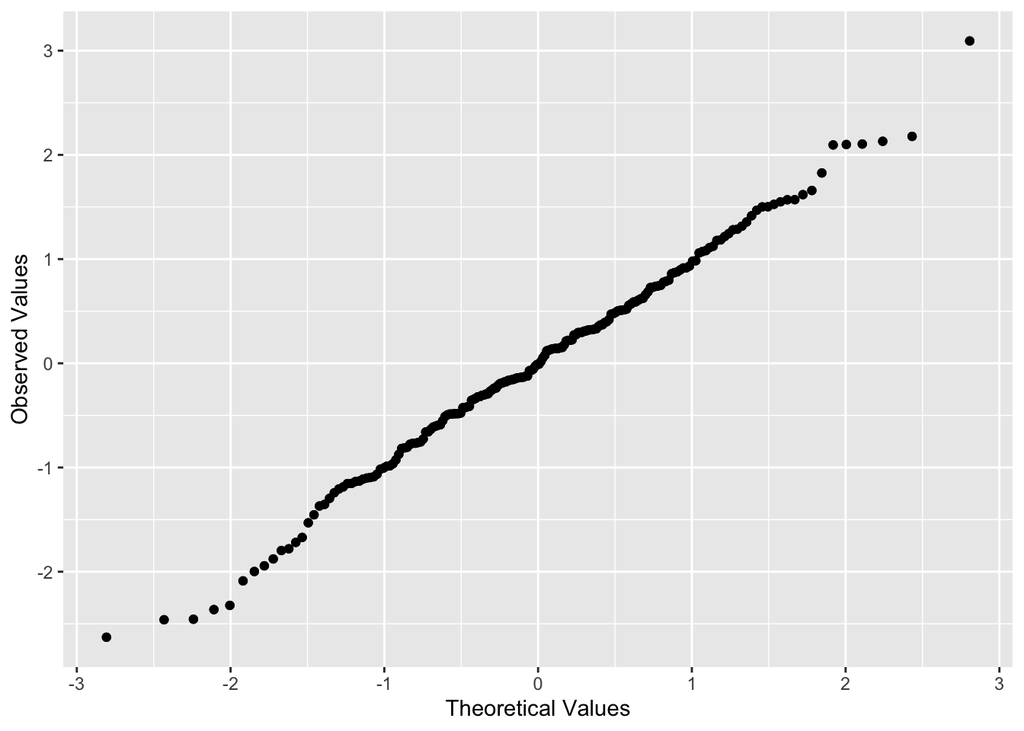

```r
library(ggplot2)
qqplot.resid <- qplot(sample = album2$standardized.residuals) + stat_qq() +
  labs(x = "Theoretical Values", y = "Observed Values")
qqplot.resid
```

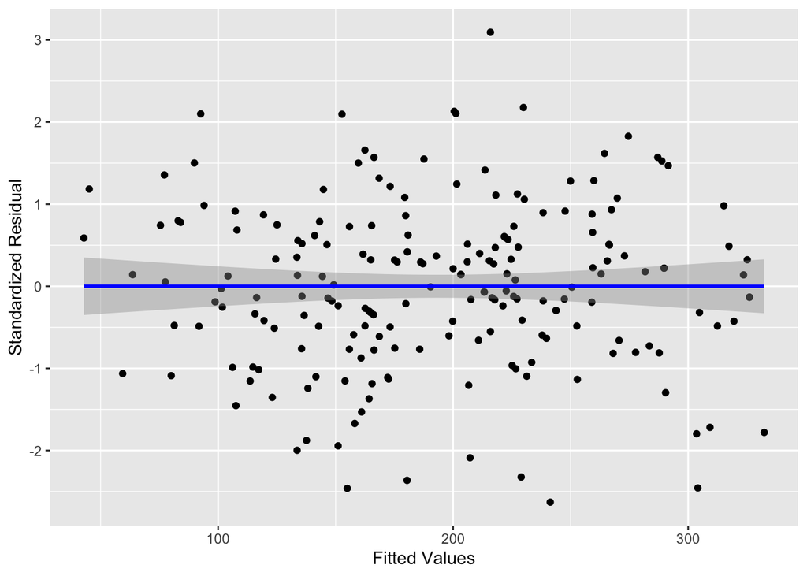

```r
album2$fitted <- albumSales.3$fitted.values
scatter <- ggplot(album2, aes(fitted, standardized.residuals))
scatter + geom_point() + geom_smooth(method = "lm", colour = "Blue") +
  labs(x = "Fitted Values", y = "Standardized Residual")
```

여기서 선형회귀분석의 가정들을 정리해보자면, 선형성 가정(linearity), 오차의 독립성 가정(iid), 정규성 가정(Normality), 등분산성(Homoscedasticity)이 있다. 또한, 다중공선성과 이상치(Outlier), 영향력(Leverage) 또한 고려해야 할 사항들이다.

### Bootstrapping

`객체 <- boot(자료, 함수, 반복)` : 이 때 ‘함수’ 란 부트스트랩 방법을 적용할 통계량 계산 함수이다. 이 때 indices를 넣어야 한다. 다음과 같은 `bootReg` 함수를 만들어 본다고 하자.

```r
library(boot)

#bootReg 함수 생성
bootReg <- function (formula, data, indices){
  d <- data [indices, ]
  fit <- lm(formula, data = d)
  return(coef(fit))
}

#bootstrapping
bootResults <- boot(statistic = bootReg, formula = sales ~ adverts + airplay + attract,
                    data = album2, R = 2000)

#boot.ci
boot.ci(bootResults, type = "bca", index = 1)
```

```
## BOOTSTRAP CONFIDENCE INTERVAL CALCULATIONS
## Based on 2000 bootstrap replicates
##
## CALL :
## boot.ci(boot.out = bootResults, type = "bca", index = 1)
##
## Intervals :
## Level       BCa
## 95%   (-57.17,   6.56 )
## Calculations and Intervals on Original Scale
```

이 때, `type = "bca"` 는 bias corrected accelerated로, 부트스트랩 신뢰구간의 instensive한 부분을 보완하고자 하는 데 있다 (부트스트랩은 정규성 가정을 두고 하는 것이 아니기 때문에)

bootstrapping과 관련해서는 구체적인 사용 예시를 더 연구해보도록 하자 (ISLR에도 해당 예시가 많이 나와있다).

### Multicategorical Regression

```r
gfr <- read.delim("GlastonburyFestivalRegression.dat", header = TRUE)
gfr$music <- as.factor(gfr$music)
contrasts(gfr$music) <- contr.treatment(4, base = 4)
gfr$music
```

이렇게 하면 factor화된 variable의 4번 값을 baseline group으로 설정하게 된다. 이렇게 하는 방법이 있는가 하면, 각 Dummy Variable 이름을 내가 설정할 수 있는 방법이 있기도 하다.

```r
crusty_v_NMA <- c(1,0,0,0)
indie_v_NMA <- c(0,1,0,0)
metal_v_NMA <- c(0,0,1,0)
contrasts(gfr$music) <- cbind(crusty_v_NMA, indie_v_NMA, metal_v_NMA)
gfr$music
```

이를 이용하여 다범주형 회귀분석을 실시해보자.

```r
glastonburyModel <- lm(change ~ music, data = gfr)
summary(glastonburyModel)
```

```
##
## Call:
## lm(formula = change ~ music, data = gfr)
##
## Residuals:
##      Min       1Q   Median       3Q      Max
## -1.82569 -0.50489  0.05593  0.42430  1.59431
##
## Coefficients:
##                   Estimate Std. Error t value Pr(>|t|)
## (Intercept)       -0.55431    0.09036  -6.134 1.15e-08 ***
## musiccrusty_v_NMA -0.41152    0.16703  -2.464   0.0152 *
## musicindie_v_NMA  -0.40998    0.20492  -2.001   0.0477 *
## musicmetal_v_NMA   0.02838    0.16033   0.177   0.8598
## ---
## Signif. codes:  0 '***' 0.001 '**' 0.01 '*' 0.05 '.' 0.1 ' ' 1
##
## Residual standard error: 0.6882 on 119 degrees of freedom
##   (687 observations deleted due to missingness)
## Multiple R-squared:  0.07617,    Adjusted R-squared:  0.05288
## F-statistic:  3.27 on 3 and 119 DF,  p-value: 0.02369
```

```r
#사실 R이 Data file을 가져올 때 알아서 범주형 변수를 Factorize 한다고는 한다. 하지만 첫째 변수를 reference group으로 삼기 때문에 변경을 위해서는 위와 같은 조작이 필요하다.
```

## 8. Logistic Regression